# **NFL Teams: Where does success come from?**

by Smit Patel, Tim Clifford, and Shyam Patel

## **Introduction**

[figure not shown]

National Football League, otherwise known as the NFL is the highest level of professional American football. It was founded on September 17, 1920, in Canton, OH, with its inaugural season being also in 1920. The league consists of 32 teams, divided equally between the American Football Conference (AFC) and the National Football Conference (NFC). A plentiful amount of attention is drawn to this sport, given its status of high-skill football. There are a variety of invested parties ranging from the players, fans, coaches, owners, bettors, and many more. Each team is fighting for the crown jewel of the NFL each and every season: the super bowl title. Each player is putting their body on the line for glory.

Every team in the NFL is of the highest professional caliber, so you may be wondering what makes a team stand out from the rest. What gave a team the edge to make it to the Super Bowl game, lay claim to its title every season, and leave the rest of the teams in the mud? Could there be clues hidden deep within the statistics of the NFL games (passing yards, etc.)? This leads us to the goal/motivation of the project. To decipher where do teams’ successes come from? Furthermore, it can be useful to analyze specific positions on football team, and how that position's effectiveness translates to wins and losses for a team. These statistics are significant to a wide array of people, not only fans of a team that want to see their team win. For example, fantasy football is an extremely popular hobby played by millions of Americans and people world-wide. This entails "drafting" certain players to your team, where you as if you are a manager, and is largely dependent on how you think will produce best at each position.

Before we proceed with our analysis, we will lay out some background information of the sport of American Football, as our audience may range in knowledge on the subject. In football, there are 2 teams, and one is playing offense (trying to score), while the other is playing defense and trying to stop the offense. The game is played through a series of passing and running plays mainly, and the goal for the offense is go from one end of the field to the other end of the field (a touchdown) while the defense trys to stop this. There are many different positions on a football team, but for this project we will highlight some of the more statistically relevant ones. The quarterback, or QB, is the most important position, and essentially controls the offense as they are throwing. The Wide Receivers (WR), main goal is to catch the passes, and the Running Backs (RB) who try to run the ball. The aforementioned should give a good enough understanding of the game to understand the significane of the following analysis.

The information proceeding contains NFL statistics from CBS Sports. The NFL and CBS have had a lucrative relationship for decades. The network has aired NFL games and/or other NFL-related shows since 1956.

Sidenote: Fly Eagles Fly

```python
# Imports for the project
import pandas as pd
from bs4 import BeautifulSoup
import requests
import matplotlib.pyplot as plt
import numpy as np
import seaborn as sns
from sklearn.linear_model import LinearRegression as lr
from statsmodels.formula.api import ols
```

## **Data Collection**

W. Edwards Deming stated "Without data, you're just another person with an opinion." The code cells below show you how we begin data collection.

We start by collecting data about the individual players in there areas: passing, rushing, and receiving. To do this, we take in the html pages from CBS Sport and extract the tables from the pages into dataframes.

An important note, please take into consideration the time this project was completed. This project and its content may be subject to changes. For us, it is currently the 2022 NFL season, week 14.

```python
# 2022 player passing statistics
page = requests.get('https://www.cbssports.com/nfl/stats/player/passing/nfl/regular/qualifiers/?sortdir=descending&sortcol=yds')
soup = BeautifulSoup(page.content, 'html.parser')
htmltable = soup.find_all("table")
table = pd.read_html(str(htmltable[0]))
passing_df = table[0]

# 2022 player rushing statistics
page = requests.get('https://www.cbssports.com/nfl/stats/player/rushing/nfl/regular/qualifiers/')
soup = BeautifulSoup(page.content, 'html.parser')
htmltable = soup.find_all("table")
table = pd.read_html(str(htmltable[0]))
rushing_df = table[0]

# 2022 player receiving statistics
page = requests.get('https://www.cbssports.com/nfl/stats/player/receiving/nfl/regular/qualifiers/')
soup = BeautifulSoup(page.content, 'html.parser')
htmltable = soup.find_all("table")
table = pd.read_html(str(htmltable[0]))
receiving_df = table[0]
```

In the code cell below, we will extract team data. This data includes total team offensive yards, points, defensive yards, etc. from the CBS Sports website. The same method as above is used.

```python
# 2022 team offensive statistics
page = requests.get('https://www.cbssports.com/nfl/stats/team/team/total/nfl/regular/')
soup = BeautifulSoup(page.content, 'html.parser')
htmltable = soup.find_all("table")
table = pd.read_html(str(htmltable[0]))
teamoffense_df = table[0]

# 2022 team defensive statistics
page = requests.get('https://www.cbssports.com/nfl/stats/team/opponent/total/nfl/regular/')
soup = BeautifulSoup(page.content, 'html.parser')
htmltable = soup.find_all("table")
table = pd.read_html(str(htmltable[0]))
teamdefense_df = table[0]
```

The last piece of data we will extract comes from teamrankings.com. This data comprises of NFL standings (team win/loss counts and rates). This is the primary focus of the project. We aim to answer the question of what stats correlate to success -- measured by number of team wins.

```python
# 2022 NFL standings statistics (from teamrankings.com)
page = requests.get('https://www.teamrankings.com/nfl/trends/win_trends/')
soup = BeautifulSoup(page.content, 'html.parser')
htmltable = soup.find_all("table")
table = pd.read_html(str(htmltable[0]))
standings_df = table[0]
```

## **Data Cleanse**

The data is not perfect. Some of the dataframes are a little messy. Some may have too much information. Some may have unclean column names/values. In the code cells below, we will tidy up all the dataframes so that we can analyze the information we need.

The passing, rushing, and receiving dataframes all need to be restructured to more simply contain the correct stats we will want to evaluate later.

```python
# Let us define a function to convert 3-Character IDs into city names so we can compare player and team stats, unfortunately this
# is very brute-force esque as there is no functional way to create the mapping we need

dict = {'KC': 'Kansas City', 'CIN': 'Cincinnati', 'BUF': 'Buffalo', 'LAC': 'L.A. Chargers', 'TB': 'Tampa Bay',
        'SEA': 'Seattle', 'DET': 'Detroit', 'LV': 'Las Vegas', 'PHI': 'Philadelphia',
        'MIN': 'Minnesota', 'IND': 'Indianapolis', 'GB': 'Green Bay', 'MIA': 'Miami', 'JAC': 'Jacksonville',
        'CLE': 'Cleveland', 'DEN': 'Denver', 'SF': 'San Francisco', 'NYG': 'N.Y. Giants', 'ARI': 'Arizona', 'NO': 'New Orleans',
        'BAL': 'Baltimore', 'ATL': 'Atlanta', 'HOU': 'Houston', 'TEN': 'Tennessee', 'LAR': 'L.A. Rams', 'NE': 'New England',
        'CHI': 'Chicago', 'PIT': 'Pittsburgh', 'DAL': 'Dallas', 'WAS': 'Washington', 'NYJ': 'N.Y. Jets', 'CAR': 'Carolina'}
def idToCity(x):
  return dict[x]
```

```python
# Tidying up the passing dataframe

# Create column for Player
passing_df["Player"] = passing_df["Player  Player on team"].apply(lambda x: x.split(" ")[0] + " " + x.split(" ")[1])

# Create column for Team
passing_df["Team"] = passing_df["Player  Player on team"].apply(lambda x: x.split(" ")[-1])

# Create column for Position
passing_df["Position"] = passing_df["Player  Player on team"].apply(lambda x: x.split(" ")[-3])

# Dropping columns
passing_df = passing_df.drop(columns = ["Player  Player on team", "LNG  Longest Completion", "YDSL  Sack Yards Lost"])

# Rename column names
passing_df = passing_df.rename(columns = {"GP  Games played": "Games Played", "ATT  Pass Attempts": "Attempts", "CMP  Pass Completions": "Completions", "PCT  Completion Percentage": "Completion %", "YDS  Passing Yards": "Passing Yards", "YDS/G  Passing Yards per Game": "Passing YPG", "TD  Touchdown Passes": "TDs", "INT  Interceptions Thrown": "INTs", "SCK  Times Sacked": "Times Sacked", "RATE  Passer Rating": "QBR"})

# Reorder columns
passing_df = passing_df[["Player", "Position", "Team", "Games Played", "Attempts", "Completions", "Completion %", "Passing Yards", "Passing YPG", "TDs", "INTs", "Times Sacked", "QBR"]]


passing_df['Team'] = passing_df['Team'].apply(lambda x: idToCity(x))
passing_df.head(5)
```

|  | Player | Position | Team | Games Played | Attempts | Completions | Completion % | Passing Yards | Passing YPG | TDs | INTs | Times Sacked | QBR |
| --- | --- | --- | --- | --- | --- | --- | --- | --- | --- | --- | --- | --- | --- |
| 0 | P. Mahomes | QB | Kansas City | 12 | 469 | 308 | 65.7 | 3808 | 317.3 | 30 | 8 | 19 | 104.9 |
| 1 | J. Burrow | QB | Cincinnati | 12 | 440 | 304 | 69.1 | 3446 | 287.2 | 25 | 8 | 34 | 103.7 |
| 2 | J. Allen | QB | Buffalo | 12 | 443 | 284 | 64.1 | 3406 | 283.8 | 25 | 11 | 25 | 96.0 |
| 3 | J. Herbert | QB | L.A. Chargers | 12 | 510 | 340 | 66.7 | 3339 | 278.3 | 20 | 7 | 26 | 92.3 |
| 4 | T. Brady | QB | Tampa Bay | 12 | 524 | 347 | 66.2 | 3332 | 277.7 | 16 | 3 | 18 | 91.6 |

```python
# Tidying up the rushing dataframe
# Same process as above, each line of code functions respectively the same
rushing_df["Player"] = rushing_df["Player  Player on team"].apply(lambda x: x.split(" ")[0] + " " + x.split(" ")[1])
rushing_df["Team"] = rushing_df["Player  Player on team"].apply(lambda x: x.split(" ")[-1])
rushing_df["Position"] = rushing_df["Player  Player on team"].apply(lambda x: x.split(" ")[-3])
rushing_df = rushing_df.drop(columns = ["Player  Player on team", "LNG  Longest Rush"])
rushing_df = rushing_df.rename(columns = {"GP  Games played": "Games Played", "ATT  Rushing Attempts": "Attempts", "YDS  Rushing Yards": "Rushing Yards", "YDS/G  Rushing Yards per Game": "Rushing YPG", "AVG  Average Yards per Rush": "Rushing AVG", "TD  Rushing Touchdowns": "TDs"})
rushing_df = rushing_df[["Player", "Position", "Team", "Games Played", "Attempts", "Rushing Yards", "Rushing AVG", "Rushing YPG", "TDs"]]
rushing_df['Team'] = rushing_df['Team'].apply(lambda x: idToCity(x))
rushing_df.head(5)
```

|  | Player | Position | Team | Games Played | Attempts | Rushing Yards | Rushing AVG | Rushing YPG | TDs |
| --- | --- | --- | --- | --- | --- | --- | --- | --- | --- |
| 0 | J. Jacobs | RB | Las Vegas | 13 | 269 | 1402 | 5.2 | 107.8 | 11 |
| 1 | N. Chubb | RB | Cleveland | 12 | 217 | 1119 | 5.2 | 93.3 | 12 |
| 2 | D. Henry | RB | Tennessee | 12 | 258 | 1078 | 4.2 | 89.8 | 10 |
| 3 | S. Barkley | RB | N.Y. Giants | 12 | 242 | 1055 | 4.4 | 87.9 | 8 |
| 4 | D. Cook | RB | Minnesota | 12 | 198 | 927 | 4.7 | 77.3 | 7 |

```python
# Tidying up the receiving dataframe
# Same process as two cells above, each line of code functions respectively the same
receiving_df["Player"] = receiving_df["Player  Player on team"].apply(lambda x: x.split(" ")[0] + " " + x.split(" ")[1])
receiving_df["Team"] = receiving_df["Player  Player on team"].apply(lambda x: x.split(" ")[-1])
receiving_df["Position"] = receiving_df["Player  Player on team"].apply(lambda x: x.split(" ")[-3])
receiving_df = receiving_df.drop(columns = ["Player  Player on team", "LNG  Longest Reception"])
receiving_df = receiving_df.rename(columns = {"GP  Games played": "Games Played", "REC  Receptions": "Receptions", "YDS  Receiving Yards": "Receiving Yards", "YDS/G  Receiving Yards per Game": "Receiving YPG", "AVG  Average Yards per Reception": "Receiving AVG", "TD  Receiving Touchdowns": "TDs"})
receiving_df = receiving_df[["Player", "Position", "Team", "Games Played", "Receptions", "Receiving Yards", "Receiving AVG", "Receiving YPG", "TDs"]]
receiving_df['Team'] = receiving_df['Team'].apply(lambda x: idToCity(x))
receiving_df.head(5)
```

|  | Player | Position | Team | Games Played | Receptions | Receiving Yards | Receiving AVG | Receiving YPG | TDs |
| --- | --- | --- | --- | --- | --- | --- | --- | --- | --- |
| 0 | T. Hill | WR | Miami | 12 | 96 | 1379 | 14.4 | 114.9 | 5 |
| 1 | J. Jefferson | WR | Minnesota | 12 | 88 | 1277 | 14.5 | 106.4 | 6 |
| 2 | D. Adams | WR | Las Vegas | 13 | 82 | 1247 | 15.2 | 95.9 | 12 |
| 3 | S. Diggs | WR | Buffalo | 12 | 91 | 1202 | 13.2 | 100.2 | 10 |
| 4 | J. Waddle | WR | Miami | 12 | 57 | 972 | 17.1 | 81.0 | 6 |

The team offense and defensive statistics are currently held in dataframes with multiple headers per column, so we want to simplify that as shown below.

```python
# Tidying up the offensive teams dataframe

# Create Team column
teamoffense_df["Team"] = teamoffense_df["Unnamed: 0_level_0"]

# Create Games Played column
teamoffense_df["Games Played"] = teamoffense_df["Unnamed: 1_level_0"]

# Create Total Yards column
teamoffense_df["Total Yards"] = teamoffense_df["total"]["YDS  Total Yards"]

# Create Total YPG column
teamoffense_df["Total YPG"] = teamoffense_df["total"]["YDS/G  Total Yards Per Game"]

# Create Passing Yards column
teamoffense_df["Passing Yards"] = teamoffense_df["passing"]["YDS  Passing Yards"]

# Create Passing YPG column
teamoffense_df["Passing YPG"] = teamoffense_df["passing"]["YDS/G  Passing Yards per Game"]

# Create Rushing Yards column
teamoffense_df["Rushing Yards"] = teamoffense_df["rushing"]["YDS  Rushing Yards"]

# Create Rushing YPG column
teamoffense_df["Rushing YPG"] = teamoffense_df["rushing"]["YDS/G  Rushing Yards per Game"]

# Create Points For column
teamoffense_df["Points For"] = teamoffense_df["points"]["PTS  Total Points"]

# Create PPG column
teamoffense_df["PPG"] = teamoffense_df["points"]["PTS/G  Points per Game"]

# Dropping columns
teamoffense_df = teamoffense_df.drop(columns = ["Unnamed: 0_level_0", "Unnamed: 1_level_0", "total", "passing", "rushing", "points"])

teamoffense_df.head(5)
```

|  | Team | Games Played | Total Yards | Total YPG | Passing Yards | Passing YPG | Rushing Yards | Rushing YPG | Points For | PPG |
| --- | --- | --- | --- | --- | --- | --- | --- | --- | --- | --- |
| 0 | Kansas City | 12 | 5079 | 423.3 | 3808 | 317.3 | 1401 | 116.8 | 350 | 29.2 |
| 1 | Buffalo | 12 | 4930 | 410.8 | 3414 | 284.5 | 1636 | 136.3 | 333 | 27.8 |
| 2 | Philadelphia | 12 | 4659 | 388.3 | 2974 | 247.8 | 1855 | 154.6 | 338 | 28.2 |
| 3 | Miami | 12 | 4562 | 380.2 | 3659 | 304.9 | 1076 | 89.7 | 299 | 24.9 |
| 4 | Cincinnati | 12 | 4469 | 372.4 | 3491 | 290.9 | 1211 | 100.9 | 312 | 26.0 |

```python
# Tidying up the defensive teams dataframe
# Same process as above, each line of code functions respectively the same
teamdefense_df["Team"] = teamdefense_df["Unnamed: 0_level_0"]
teamdefense_df["Games Played"] = teamdefense_df["Unnamed: 1_level_0"]
teamdefense_df["Total Yards"] = teamdefense_df["total"]["YDS  Total Yards"]
teamdefense_df["Total YPG"] = teamdefense_df["total"]["YDS/G  Total Yards Per Game"]
teamdefense_df["Passing Yards"] = teamdefense_df["passing"]["YDS  Passing Yards"]
teamdefense_df["Passing YPG"] = teamdefense_df["passing"]["YDS/G  Passing Yards per Game"]
teamdefense_df["Rushing Yards"] = teamdefense_df["rushing"]["YDS  Rushing Yards"]
teamdefense_df["Rushing YPG"] = teamdefense_df["rushing"]["YDS/G  Rushing Yards per Game"]
teamdefense_df["Points Allowed"] = teamdefense_df["points"]["PTS  Total Points"]
teamdefense_df["PPG"] = teamdefense_df["points"]["PTS/G  Points per Game"]
teamdefense_df = teamdefense_df.drop(columns = ["Unnamed: 0_level_0", "Unnamed: 1_level_0", "total", "passing", "rushing", "points"])
teamdefense_df.head(5)
```

|  | Team | Games Played | Total Yards | Total YPG | Passing Yards | Passing YPG | Rushing Yards | Rushing YPG | Points Allowed | PPG |
| --- | --- | --- | --- | --- | --- | --- | --- | --- | --- | --- |
| 0 | San Francisco | 12 | 3407 | 283.9 | 2742 | 228.5 | 907 | 75.6 | 190 | 15.8 |
| 1 | Philadelphia | 12 | 3557 | 296.4 | 2436 | 203.0 | 1415 | 117.9 | 226 | 18.8 |
| 2 | Denver | 12 | 3655 | 304.6 | 2438 | 203.2 | 1441 | 120.1 | 204 | 17.0 |
| 3 | N.Y. Jets | 12 | 3684 | 307.0 | 2563 | 213.6 | 1352 | 112.7 | 223 | 18.6 |
| 4 | Dallas | 12 | 3715 | 309.6 | 2480 | 206.7 | 1557 | 129.8 | 206 | 17.2 |

The standings dataframe does not show the wins vs losses vs ties in separate columns, so we can fix this as well quickly.

```python
# Renaming teams so they are univerally understood in all dataframes
def rename(team):
  if team == "NY Jets":
    return "N.Y. Jets"
  elif team == "NY Giants":
    return "N.Y. Giants"
  elif team == "LA Rams":
    return "L.A. Rams"
  elif team == "LA Chargers":
    return "L.A. Chargers"
  else:
    return team

# Tidying up the standings dataframe
standings_df["Wins"] = standings_df["Win-Loss Record"].apply(lambda x: x.split("-")[0])
standings_df["Losses"] = standings_df["Win-Loss Record"].apply(lambda x: x.split("-")[1])
standings_df["Ties"] = standings_df["Win-Loss Record"].apply(lambda x: x.split("-")[2])
standings_df = standings_df.drop(columns = ["Win-Loss Record", "MOV", "ATS +/-"])
standings_df = standings_df[["Team", "Wins", "Losses", "Ties", "Win %"]]
standings_df["Team"] = standings_df["Team"].apply(rename)
standings_df.head(5)
```

|  | Team | Wins | Losses | Ties | Win % |
| --- | --- | --- | --- | --- | --- |
| 0 | Philadelphia | 11 | 1 | 0 | 91.7% |
| 1 | Minnesota | 10 | 2 | 0 | 83.3% |
| 2 | Kansas City | 9 | 3 | 0 | 75.0% |
| 3 | Buffalo | 9 | 3 | 0 | 75.0% |
| 4 | Dallas | 9 | 3 | 0 | 75.0% |

## **Exploratory Analysis**

This is where the fun begins. We have our data in their respective dataframes. We can begin data analysis and try to see what individual/team statistics create wins for teams, if any.

First, let's display the NFL standings.

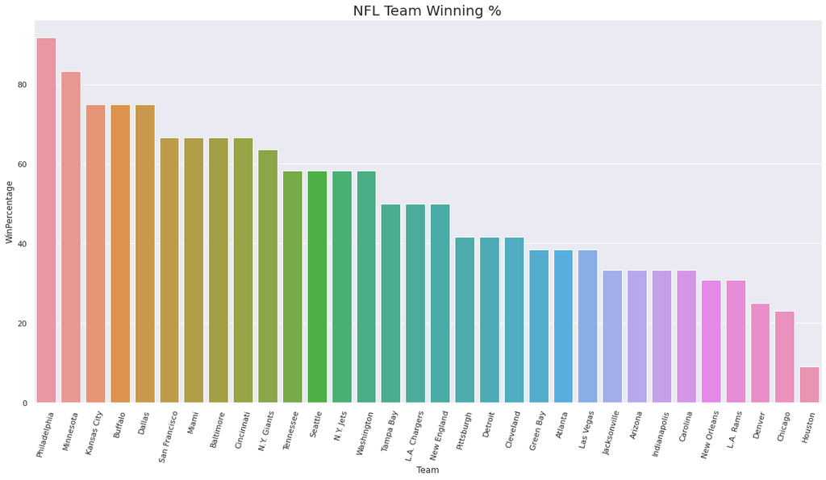

```python
# Create temp dataframe
temp = pd.DataFrame().assign(Team = standings_df["Team"], WinPercentage = standings_df["Win %"].apply(lambda x: float(x[0:-1])))

# Create sns bar plot
sns.set(rc={'figure.figsize':(20,10)})
plt.xticks(rotation=75)
plt.title("NFL Team Winning %", fontsize=20)
sns.barplot(data = temp, x = 'Team', y = 'WinPercentage')
```

Seen in the graph above, the best teams by winning percentage in the NFL are currently Philadelphia, Minnesota, Buffalo, Kansas City, and Dallas. The worst teams by win percentage are Houston, Chicago, LA Rams, Denver, and New Orleans.

Why are some of these teams garnering success while others aren't? Let's dive into some team statistics.

In the NFL, points seem intuitively important to get, as winning games relies on outscoring your opponent. So let's evaluate teams' offensive point totals versus their win percentage.

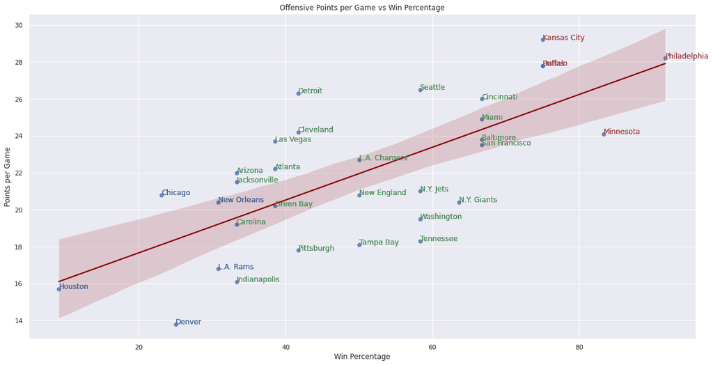

```python
#Gather the data for the scatterplot
teams = standings_df["Team"]
xs = []
ys = []
for team in teams:
  xs.append(float(list(standings_df[standings_df["Team"] == team]["Win %"])[0][0:-1]))
  ys.append(list(teamoffense_df[teamoffense_df["Team"] == team]["PPG"])[0])
# Display scatterplot
categories = np.array([0, 0, 0, 0, 0, 1, 1, 1, 1, 1, 1, 1, 1, 1, 1, 1, 1, 1, 1, 1, 1, 1, 1, 1, 1, 1, 1, 2, 2, 2, 2, 2])
colormap = np.array(['r', 'g', 'b'])

offense_df = pd.DataFrame().assign(WinPercentage = xs, PPG = ys)
sns.regplot(data = offense_df, x = 'WinPercentage', y = "PPG", line_kws={'color':'darkred'})
plt.title("Offensive Points per Game vs Win Percentage")
for i in range(len(teams)):
    plt.text(x = xs[i], y = ys[i], s = teams[i])
    plt.annotate(xy = (xs[i], ys[i]), s = teams[i], color = colormap[categories[i]])
plt.xlabel("Win Percentage")
plt.ylabel("Points per Game")
```

We highlighted the the 5 teams with the highest winning percentage in red text, leaving the 5 teams with the lowest winning percentage in blue text. Every other team has green text.

What is interesting is that the 5 teams in the red text (KC, Philadelphia, Minnesota, Buffalo, and Dallas) are not necessarily the top 5 teams based on points per game; though, the correlation is close. Are there other influencing factors? A similar statement can be made about the lowest 5 winning teams in blue text (Houston, Denver, L.A Rams, New Orleans, and Chicago).

What else could be important? Maybe a team's defensive ability. The plot above only displayed a team's offensive points per game, but it also seems important that a team's denfensive side doesn't allow many points per game if the team wants to win. Let's evaluate team's defensive points per game vs team winning percentages as well, below.

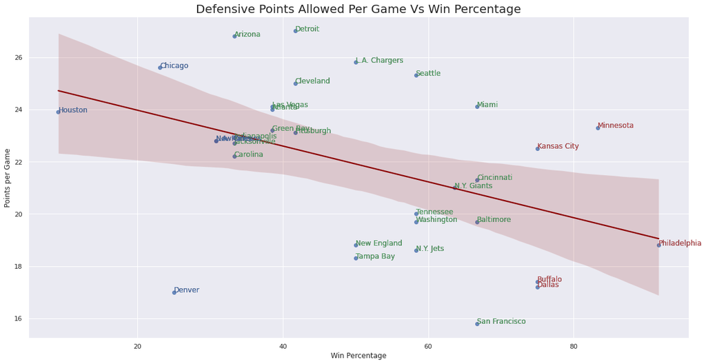

```python
# Gather the data for the scatterplot
teams = standings_df["Team"]
xs = []
ys = []
for team in teams:
  xs.append(float(list(standings_df[standings_df["Team"] == team]["Win %"])[0][0:-1]))
  ys.append(list(teamdefense_df[teamdefense_df["Team"] == team]["PPG"])[0])

# Create sns scatter plot
temp = pd.DataFrame().assign(WinPercentage = xs, PPG = ys)
sns.regplot(data = temp, x = 'WinPercentage', y = 'PPG', line_kws={'color':'darkred'})
plt.title("Defensive Points Allowed Per Game Vs Win Percentage", fontsize=20)

# Add team names to each point
for i in range(len(teams)):
    plt.text(x = xs[i], y = ys[i], s = teams[i])
    plt.annotate(xy = (xs[i], ys[i]), s = teams[i], color = colormap[categories[i]])
plt.xlabel("Win Percentage")
plt.ylabel("Points per Game")
```

This graph adds a little twist to our understanding. This graph shows much less correlation between defensive points allowed per game and a team's winning percentage. Like in the graph above, the five best and worst teams by win percentages are colored red/blue respectively.

A few of the best teams appear to have a good defense (based on points allowed, with lower points being better defense), it is not universal to all the best teams. Kansas City and Minnesota have just above 22 ppg allowed for example. Interestingly, you'll see that one of the worst winning teams in the league, Denver, has one of the best defenses.

Since there seems to be a better correlation between offesnive points per game and team winning percentages than defensive points allowed per game, let's diver deeper down this route and try to see what team or player statsitcs tend to help garner points.

It seems intuitive that in the game of football, the more offensive yards a team gets, the more points they would gain, so we will look at that first.

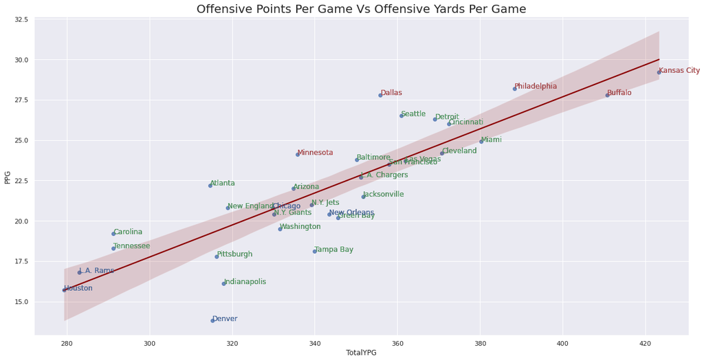

```python
# Gather the data for the scatterplot
teams = standings_df["Team"]
xs = []
ys = []
for team in teams:
  xs.append(list(teamoffense_df[teamoffense_df["Team"] == team]["Total YPG"])[0])
  ys.append(list(teamoffense_df[teamoffense_df["Team"] == team]["PPG"])[0])

# Create sns scatter plot
temp = pd.DataFrame().assign(TotalYPG = xs, PPG = ys)
sns.regplot(data = temp, x = 'TotalYPG', y = 'PPG', line_kws={'color':'darkred'})
plt.title("Offensive Points Per Game Vs Offensive Yards Per Game", fontsize=20)

# Add team names to each point
for i in range(len(teams)):
    plt.text(x = xs[i], y = ys[i], s = teams[i])
    plt.annotate(xy = (xs[i], ys[i]), s = teams[i], color = colormap[categories[i]])
```

Looking at the graph above, a teams' offensive yards per game has a very strong correlation to their points per game, which has some correlation to wins. Let's see how team's get their yards (passing, rushing), and if either of these could potentially have a larger impact on if a team is going to win or not.

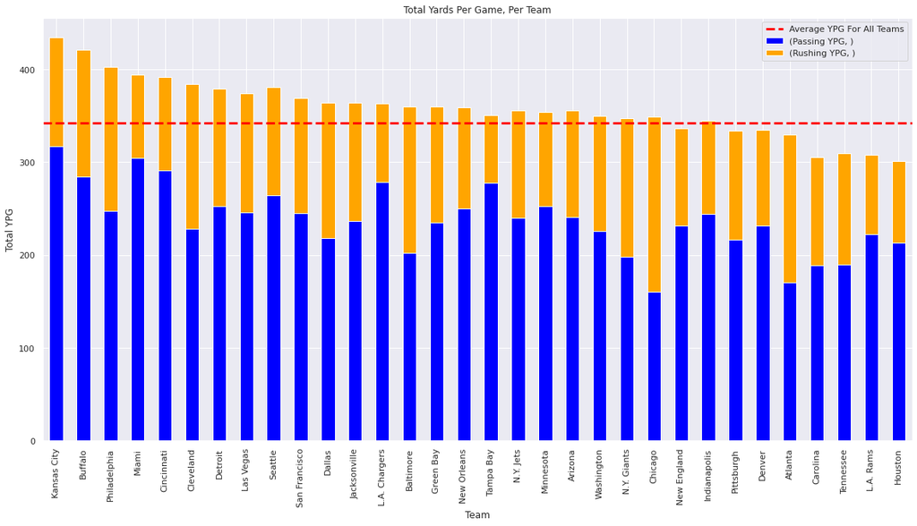

```python
# Plot the Total Yards Per Game as a stacked bar chart
ax = teamoffense_df.plot(kind='bar', stacked=True, x='Team', y=['Passing YPG', 'Rushing YPG'], color=['blue', 'orange'], title = "Total Yards Per Game, Per Team", ylabel = "Total YPG")
ax.axhline(teamoffense_df["Total YPG"].mean(), color="red", linestyle="--", label="Average YPG For All Teams", linewidth = 3)
ax.legend()

# Show the plot
plt.show()
```

Note on the Graph: For this plot, we made a modified version of a bar plot depicting the total yards per game for each team, while showing the effective split between rushing and passing. The red is to indicate the average of all teams YPG.

It's interesting to note how many of the teams gain their yards primarily through passing and supplementary through rushing. In fact, it looks like Chicago, Atlanta, and Baltimore could possibly have more rushing yards than offense. An interesting point to notice about these teams, is that in addition to a strong rushing game from their running backs, they all have what are known as "mobile QBs" or "Dual Threat QBs". These quarterbacks have the abaility to run, known as scrambling, effectively when they do not see a receiver open and thus can create a new form of offense. The effect of these dual threat QBs can possilby effect offenses in interesting ways, and we may explore it later to analyze that on a team's ability to win.

Fun Fact: UMD's 4th string QB on our football team this year was a "Dual Threat" in highschool, if you so desire, check him out here: https://umterps.com/sports/football/roster/ryan-duell/10304

Now let's double check how effectively teams prevent points then by examining the scatterplot of defensive points per game allowed vs yards allowed per game allowed.

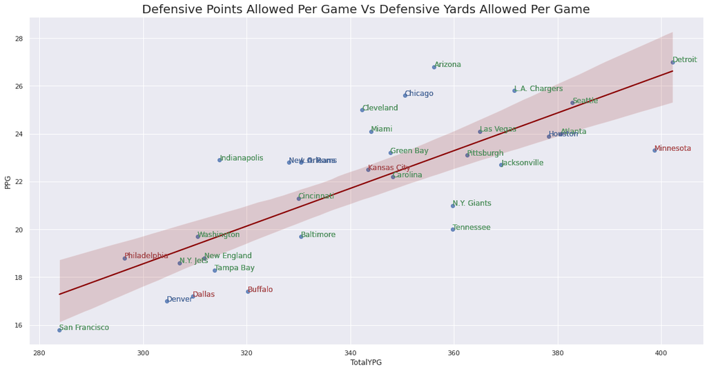

```python
# Gather the data for the scatterplot
teams = standings_df["Team"]
xs = []
ys = []
for team in teams:
  xs.append(list(teamdefense_df[teamdefense_df["Team"] == team]["Total YPG"])[0])
  ys.append(list(teamdefense_df[teamdefense_df["Team"] == team]["PPG"])[0])

# Create sns scatter plot
temp = pd.DataFrame().assign(TotalYPG = xs, PPG = ys)
sns.regplot(data = temp, x = 'TotalYPG', y = 'PPG', line_kws={'color':'darkred'})
plt.title("Defensive Points Allowed Per Game Vs Defensive Yards Allowed Per Game", fontsize=20)

# Add team names to each point
for i in range(len(teams)):
    plt.text(x = xs[i], y = ys[i], s = teams[i])
    plt.annotate(xy = (xs[i], ys[i]), s = teams[i], color = colormap[categories[i]])
```

Note on plot: Since this a scatterplot is showing defensive statistics, a team that generally allows less yards, and less points would be better, so data towards the lower left, represent the best teams for these critiera while teams in the upper right represent teanms that allow the most defensive yards and touchdowns, and thus may have a poor defense.

Although it seems clear that allowing less yards defensively typically aligns to allowing less points per game defensively, what is also clear is that this can be independent of whether a team wins. This is highlighted by the red and blue names, representing the five highest/lowest win percentage teams, which are scattered all over this plot. In other words, do the wide spread of the teams with the best records in relation to the amount of yards they allow/defensive touchdowns, it may be interesting to note that an offense may be more important for team success than their defense. From a pure NFL perspective, this may be why teams such as the Bengals, who were abysaml a couple years ago, focused on drafting an elite WR and an an elite QB (Ja'Marr Chase and Joe Burrow respectively, for my football fans), try to build their team around a young offensive core. One could note that this worked, as the Bengals were the in Superbowl last year.

One last thing to check on teams is if a team's defense helps a team's offense, or vice versa. Because although offensive yards/points seems generally more significant to wins, that team's defensive play may be aiding their offensive play in the first place and that's something we want to look at and consider.

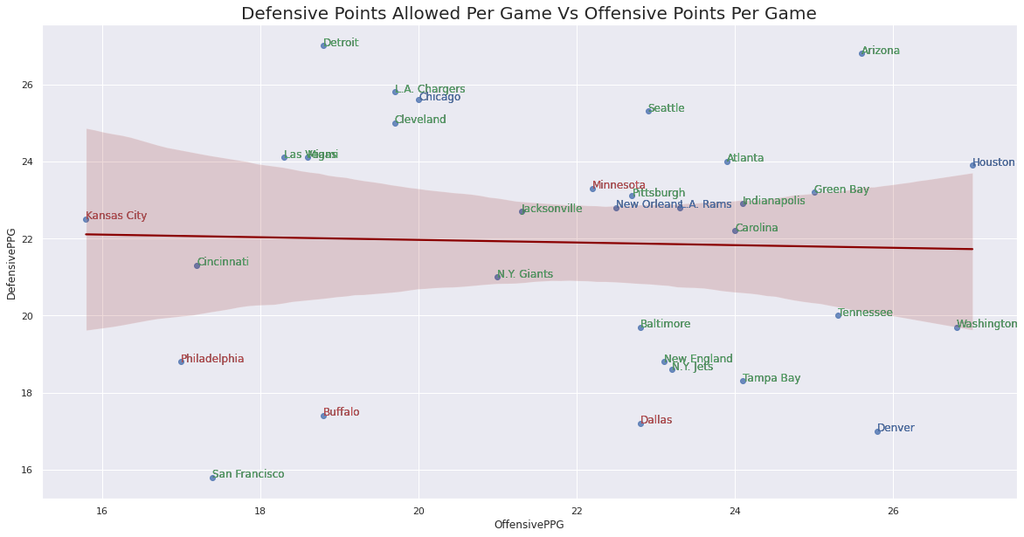

```python
# Gather the data for the scatterplot
teams = standings_df["Team"]
xs = []
ys = []
for team in teams:
  xs.append(list(teamdefense_df[teamoffense_df["Team"] == team]["PPG"])[0])
  ys.append(list(teamdefense_df[teamdefense_df["Team"] == team]["PPG"])[0])

# Create sns scatter plot
temp = pd.DataFrame().assign(OffensivePPG = xs, DefensivePPG = ys)
sns.regplot(data = temp, x = 'OffensivePPG', y = 'DefensivePPG', line_kws={'color':'darkred'})
plt.title("Defensive Points Allowed Per Game Vs Offensive Points Per Game", fontsize=20)

# Add team names to each point
for i in range(len(teams)):
    plt.text(x = xs[i], y = ys[i], s = teams[i])
    plt.annotate(xy = (xs[i], ys[i]), s = teams[i], color = colormap[categories[i]])
```

So from this first part of data exploration, it seems that in general offensive performance is significantly more important to producing wins than defensive performance. Because of this, we want to delve into individual offensive player data, to see if players (individually) have strong effects on wins. This is where QB ratings come into play.

## **Data Analysis**

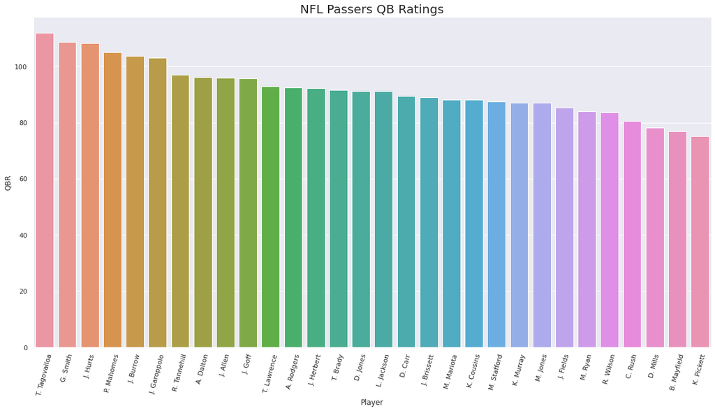

```python
# Create temp dataframe
temp = pd.DataFrame().assign(Player = passing_df["Player"], QBR = passing_df["QBR"], Team = passing_df["Team"], GamesPlayed = passing_df["Games Played"], Sacked = passing_df["Times Sacked"])
temp = temp[temp["GamesPlayed"] >= 8]
temp = temp.sort_values(by = "QBR", ascending = False)

# Create sns bar plot
sns.set(rc={'figure.figsize':(20,10)})
plt.xticks(rotation=75)
plt.title("NFL Passers QB Ratings", fontsize=20)
sns.barplot(data = temp, x = 'Player', y = 'QBR')
```

The NFL has a metric for passers called QBR (Quarterback Rating), which supposedly determines how well a passer is playing based on their yards gained, touchdowns thrown, and interceptions thrown, among other metrics. The formula for QBR is given below:

*Note: QBR or Quarterback Rating is also referred to as the Passer Rating, so we will use these terms interchangebly from here on out*

[output not shown]

QBR is one of the most famously cited and used metrics in football, and often used to determine passing play, and thus by addition, determine how well a quarterback is playing. For reference, the maxmimum possible passer rating is 158.3, but anything above 100 is considered good (very good is kept up over the course of a season). QBR is an interesting metric, and we can use it to see how it relates to offensive production in general, along with how it is associated with a team's win percentage, as the QB is the helm of the offense.

Above in the above bar graph we can see the players (filtered out to a minimum of 8 games played, to note that they have had a significant impact on their team this season) and their QBRs. From the graph, we can see Tua Tagovailoa (MIA) has the highest rated QB rating, followed by Geno Smith (SEA), Jalen Hurts (PHI), and Patrick Mahomes (KC). Jalen Hurts and Patrick Mahomes are currently top two in the race for MVP in the NFL, so this shows that QBR definitely helps indicate who the best quarterbacks are in the league, but also that there are other things to consider.

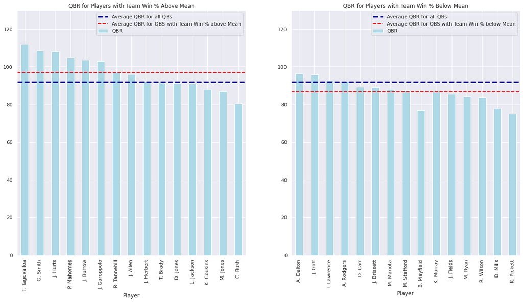

```python
# Add win percentages to the temp dataframe
temp = pd.merge(temp, standings_df[["Team", "Win %"]], on="Team")

# Compute the mean of the Team Win % column
temp["Win %"] = temp["Win %"].apply(lambda x: float(x[0:-1]))
mean_win = temp["Win %"].mean()

# Create the figure and subplots
fig, ax = plt.subplots(nrows=1, ncols=2)

# Select only the rows with a Win % value above the mean
temp_above = temp.loc[temp["Win %"] > mean_win]

# Create a subplot for players with a Win % above the mean
a = temp_above.plot(
    x="Player",
    y="QBR",
    kind="bar",
    title="QBR for Players with Team Win % Above Mean",
    color = "lightblue",
    ax=ax[0]
)
# Add lines at average values
a.axhline(temp["QBR"].mean(), color="darkblue", linestyle="--", label="Average QBR for all QBs", linewidth = 3)
a.axhline(temp_above["QBR"].mean(), color="red", linestyle="--", label="Average QBR for QBS with Team Win % above Mean", linewidth = 2)
a.set_ylim(0, 130)
a.legend()

# Select only the rows with a Win % value below the mean
temp_below = temp.loc[temp["Win %"] < mean_win]

# Create a subplot for players with a Win % below the mean
a = temp_below.plot(
    x="Player",
    y="QBR",
    kind="bar",
    title="QBR for Players with Team Win % Below Mean",
    color = "lightblue",
    ax=ax[1]
)
# Add lines at average values
a.axhline(temp["QBR"].mean(), color="darkblue", linestyle="--", label="Average QBR for all QBs", linewidth = 3)
a.axhline(temp_below["QBR"].mean(), color="red", linestyle="--", label="Average QBR for QBS with Team Win % below Mean", linewidth = 2)
a.set_ylim(0, 130)
a.legend()

# Display the plots
passing_df = temp
plt.show()
```

Let's break these bar plots down. First, the quarterbacks were split between those with winning teams above average and those with winning teams below the average. Then, each quarterbacks QBR was plotted, as well as lines representing the true average quarterback rating, as well as the averages of the two respective bar plots, which show that the average quarterback ratings for winning quarterbacks is notably higher than the average quarterback ratings for below-average winning quarterbacks. This makes intuitive sense as well, as a QB is throwing the ball better would be expected to lead his team to more wins than a QB is not able to throw the ball as accurately. Of course, it is important to note that QBR alone is not a truly effective metric, as a QB's QBR may be aided or hurt by the quality of their receivers, offensive line, and other positional players. If a QB has all-pro wide receivers that can make highly skilled and difficult catches, this may boost a QB's passer rating when they really aren't that good of a QB. A QB may also have other attributes that make them a prolific player, such as their ability to run on the ground which we will explain.

Now, let's evaluate other metrics.

```python
# Gathering more data and tidying it up

# 2022 player rushing statistics page 2
page = requests.get('https://www.cbssports.com/nfl/stats/player/rushing/nfl/regular/qualifiers/?page=2')
soup = BeautifulSoup(page.content, 'html.parser')
htmltable = soup.find_all("table")
table = pd.read_html(str(htmltable[0]))
rushing2_df = table[0]
rushing2_df["Player"] = rushing2_df["Player  Player on team"].apply(lambda x: x.split(" ")[0] + " " + x.split(" ")[1])
rushing2_df["Team"] = rushing2_df["Player  Player on team"].apply(lambda x: x.split(" ")[-1])
rushing2_df["Position"] = rushing2_df["Player  Player on team"].apply(lambda x: x.split(" ")[-3])
rushing2_df = rushing2_df.drop(columns = ["Player  Player on team", "LNG  Longest Rush"])
rushing2_df = rushing2_df.rename(columns = {"GP  Games played": "Games Played", "ATT  Rushing Attempts": "Attempts", "YDS  Rushing Yards": "Rushing Yards", "YDS/G  Rushing Yards per Game": "Rushing YPG", "AVG  Average Yards per Rush": "Rushing AVG", "TD  Rushing Touchdowns": "TDs"})
rushing2_df = rushing2_df[["Player", "Position", "Team", "Games Played", "Attempts", "Rushing Yards", "Rushing AVG", "Rushing YPG", "TDs"]]
rushing2_df['Team'] = rushing2_df['Team'].apply(lambda x: idToCity(x))

# 2022 player rushing statistics page 3
page = requests.get('https://www.cbssports.com/nfl/stats/player/rushing/nfl/regular/qualifiers/?page=3')
soup = BeautifulSoup(page.content, 'html.parser')
htmltable = soup.find_all("table")
table = pd.read_html(str(htmltable[0]))
rushing3_df = table[0]
rushing3_df["Player"] = rushing3_df["Player  Player on team"].apply(lambda x: x.split(" ")[0] + " " + x.split(" ")[1])
rushing3_df["Team"] = rushing3_df["Player  Player on team"].apply(lambda x: x.split(" ")[-1])
rushing3_df["Position"] = rushing3_df["Player  Player on team"].apply(lambda x: x.split(" ")[-3])
rushing3_df = rushing3_df.drop(columns = ["Player  Player on team", "LNG  Longest Rush"])
rushing3_df = rushing3_df.rename(columns = {"GP  Games played": "Games Played", "ATT  Rushing Attempts": "Attempts", "YDS  Rushing Yards": "Rushing Yards", "YDS/G  Rushing Yards per Game": "Rushing YPG", "AVG  Average Yards per Rush": "Rushing AVG", "TD  Rushing Touchdowns": "TDs"})
rushing3_df = rushing3_df[["Player", "Position", "Team", "Games Played", "Attempts", "Rushing Yards", "Rushing AVG", "Rushing YPG", "TDs"]]
rushing3_df['Team'] = rushing3_df['Team'].apply(lambda x: idToCity(x))

# 2022 player rushing statistics page 4
page = requests.get('https://www.cbssports.com/nfl/stats/player/rushing/nfl/regular/qualifiers/?page=4')
soup = BeautifulSoup(page.content, 'html.parser')
htmltable = soup.find_all("table")
table = pd.read_html(str(htmltable[0]))
rushing4_df = table[0]
rushing4_df["Player"] = rushing4_df["Player  Player on team"].apply(lambda x: x.split(" ")[0] + " " + x.split(" ")[1])
rushing4_df["Team"] = rushing4_df["Player  Player on team"].apply(lambda x: x.split(" ")[-1])
rushing4_df["Position"] = rushing4_df["Player  Player on team"].apply(lambda x: x.split(" ")[-3])
rushing4_df = rushing4_df.drop(columns = ["Player  Player on team", "LNG  Longest Rush"])
rushing4_df = rushing4_df.rename(columns = {"GP  Games played": "Games Played", "ATT  Rushing Attempts": "Attempts", "YDS  Rushing Yards": "Rushing Yards", "YDS/G  Rushing Yards per Game": "Rushing YPG", "AVG  Average Yards per Rush": "Rushing AVG", "TD  Rushing Touchdowns": "TDs"})
rushing4_df = rushing4_df[["Player", "Position", "Team", "Games Played", "Attempts", "Rushing Yards", "Rushing AVG", "Rushing YPG", "TDs"]]
rushing4_df['Team'] = rushing4_df['Team'].apply(lambda x: idToCity(x))

# 2022 player rushing statistics page 5
page = requests.get('https://www.cbssports.com/nfl/stats/player/rushing/nfl/regular/qualifiers/?page=5')
soup = BeautifulSoup(page.content, 'html.parser')
htmltable = soup.find_all("table")
table = pd.read_html(str(htmltable[0]))
rushing5_df = table[0]
rushing5_df["Player"] = rushing5_df["Player  Player on team"].apply(lambda x: x.split(" ")[0] + " " + x.split(" ")[1])
rushing5_df["Team"] = rushing5_df["Player  Player on team"].apply(lambda x: x.split(" ")[-1])
rushing5_df["Position"] = rushing5_df["Player  Player on team"].apply(lambda x: x.split(" ")[-3])
rushing5_df = rushing5_df.drop(columns = ["Player  Player on team", "LNG  Longest Rush"])
rushing5_df = rushing5_df.rename(columns = {"GP  Games played": "Games Played", "ATT  Rushing Attempts": "Attempts", "YDS  Rushing Yards": "Rushing Yards", "YDS/G  Rushing Yards per Game": "Rushing YPG", "AVG  Average Yards per Rush": "Rushing AVG", "TD  Rushing Touchdowns": "TDs"})
rushing5_df = rushing5_df[["Player", "Position", "Team", "Games Played", "Attempts", "Rushing Yards", "Rushing AVG", "Rushing YPG", "TDs"]]
rushing5_df['Team'] = rushing5_df['Team'].apply(lambda x: idToCity(x))
```

Note that this data is filtered to QBs with more than 8 games played. We will use the above dataframes and merge it with the original passing_df so we have more information (like players) to play with and evaluate.

```python
passing_df.head()
```

|  | Player | QBR | Team | GamesPlayed | Sacked | Win % |
| --- | --- | --- | --- | --- | --- | --- |
| 0 | T. Tagovailoa | 112.0 | Miami | 10 | 15 | 66.7 |
| 1 | G. Smith | 108.7 | Seattle | 12 | 31 | 58.3 |
| 2 | J. Hurts | 108.3 | Philadelphia | 12 | 30 | 91.7 |
| 3 | P. Mahomes | 104.9 | Kansas City | 12 | 19 | 75.0 |
| 4 | J. Burrow | 103.7 | Cincinnati | 12 | 34 | 66.7 |

```python
# Get all pages of rushing_df data in the same dataframe
rushingqbs_df = pd.concat([rushing_df, rushing2_df, rushing3_df, rushing4_df, rushing5_df])
rushingqbs_df = rushingqbs_df.loc[rushingqbs_df["Position"] == "QB"]
rushingqbs_df = pd.merge(rushingqbs_df, standings_df[["Team", "Win %"]], on="Team")
rushingqbs_df["Win %"] = rushingqbs_df["Win %"].apply(lambda x: float(x[0:-1]))
rushingqbs_df = rushingqbs_df[rushingqbs_df["Games Played"] >= 8]
rushingqbs_df = pd.merge(rushingqbs_df, passing_df, on=["Player", "Win %", "Team"])
rushingqbs_df.head()
```

|  | Player | Position | Team | Games Played | Attempts | Rushing Yards | Rushing AVG | Rushing YPG | TDs | Win % | QBR | GamesPlayed | Sacked |
| --- | --- | --- | --- | --- | --- | --- | --- | --- | --- | --- | --- | --- | --- |
| 0 | J. Fields | QB | Chicago | 12 | 128 | 905 | 7.1 | 75.4 | 8 | 23.1 | 85.4 | 12 | 40 |
| 1 | L. Jackson | QB | Baltimore | 12 | 112 | 764 | 6.8 | 63.7 | 3 | 66.7 | 91.1 | 12 | 26 |
| 2 | J. Hurts | QB | Philadelphia | 12 | 132 | 609 | 4.6 | 50.8 | 9 | 91.7 | 108.3 | 12 | 30 |
| 3 | J. Allen | QB | Buffalo | 12 | 89 | 581 | 6.5 | 48.4 | 5 | 75.0 | 96.0 | 12 | 25 |
| 4 | D. Jones | QB | N.Y. Giants | 12 | 91 | 522 | 5.7 | 43.5 | 4 | 63.6 | 91.2 | 12 | 37 |

As we mentioned above, pure QBR may not be the best way at evaluating QBs or evaluating a teams success' in general. Additionally, we mentioned interesting stats related to rushing for QBs and how this could relate to a QBs perforance. After all QBs like Lamar Jackson, Justin Fields, and Jalen Hurts are all Dual-Threat QBs, and only rating them by their passing abilites does not fully speak to their game and how they play the game. To fully incorporate a rushing QB's true impact in the game, we will examine some key variables such as Rush Yards, Rush Attempts, Touchdowns, and Sacks. Sacks might be an additional factor to consider as well, as if a QB can truly run, they may be able to evade sacks at a higher rate (thus accumlate less sacks and more rushing yards).

[output not shown]

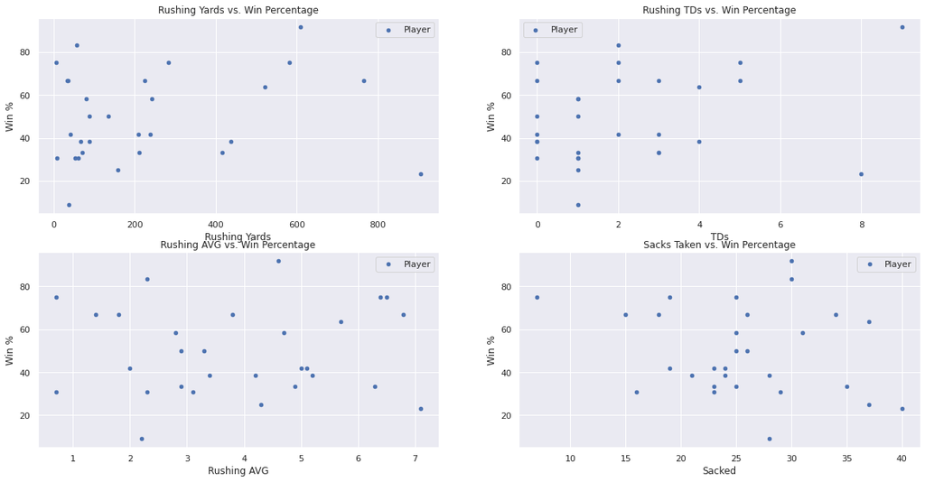

```python
# Create the figure and subplots
fig, ax = plt.subplots(nrows=2, ncols=2)

# Create a subscatter plot
a = rushingqbs_df.plot.scatter(x="Rushing Yards", y="Win %", cmap="viridis", label="Player", title="Rushing Yards vs. Win Percentage", ax = ax[0][0])

# Create second subscatter plot
a = rushingqbs_df.plot.scatter(x="Rushing AVG", y="Win %", cmap="viridis", label="Player", title="Rushing AVG vs. Win Percentage", ax = ax[1][0])

# Create third subscatter plot
a = rushingqbs_df.plot.scatter(x="TDs", y="Win %", cmap="viridis", label="Player", title="Rushing TDs vs. Win Percentage", ax = ax[0][1])

# Create fourth subscatter plot
a = rushingqbs_df.plot.scatter(x="Sacked", y="Win %", cmap="viridis", label="Player", title="Sacks Taken vs. Win Percentage", ax = ax[1][1])

# Display the plots
plt.show()
```

From observing these scatterplots and how much each variable affects the win-percentage, along with the traditonal QBR, we will now attempt to quanitfy a QB's rushing attempt on the game (via the creation of Rushing QBR Metruc), and then perform regression analysis to determine effectivenes.

```python
# Create a rushing metric equivalent to quarterback rating
rushingqbs_df = rushingqbs_df.assign(RQBR = lambda x: ((x['Rushing Yards'] / 50) + (x['Rushing AVG'] * 4) + (x['TDs'] * 4) - (x["Sacked"] / 8)) * 1.5)
rushingqbs_df = rushingqbs_df.sort_values(by='RQBR', ascending=False)
rushingqbs_df.head(5)
```

|  | Player | Position | Team | Games Played | Attempts | Rushing Yards | Rushing AVG | Rushing YPG | TDs | Win % | QBR | GamesPlayed | Sacked | RQBR |
| --- | --- | --- | --- | --- | --- | --- | --- | --- | --- | --- | --- | --- | --- | --- |
| 0 | J. Fields | QB | Chicago | 12 | 128 | 905 | 7.1 | 75.4 | 8 | 23.1 | 85.4 | 12 | 40 | 110.2500 |
| 2 | J. Hurts | QB | Philadelphia | 12 | 132 | 609 | 4.6 | 50.8 | 9 | 91.7 | 108.3 | 12 | 30 | 94.2450 |
| 3 | J. Allen | QB | Buffalo | 12 | 89 | 581 | 6.5 | 48.4 | 5 | 75.0 | 96.0 | 12 | 25 | 81.7425 |
| 1 | L. Jackson | QB | Baltimore | 12 | 112 | 764 | 6.8 | 63.7 | 3 | 66.7 | 91.1 | 12 | 26 | 76.8450 |
| 4 | D. Jones | QB | N.Y. Giants | 12 | 91 | 522 | 5.7 | 43.5 | 4 | 63.6 | 91.2 | 12 | 37 | 66.9225 |

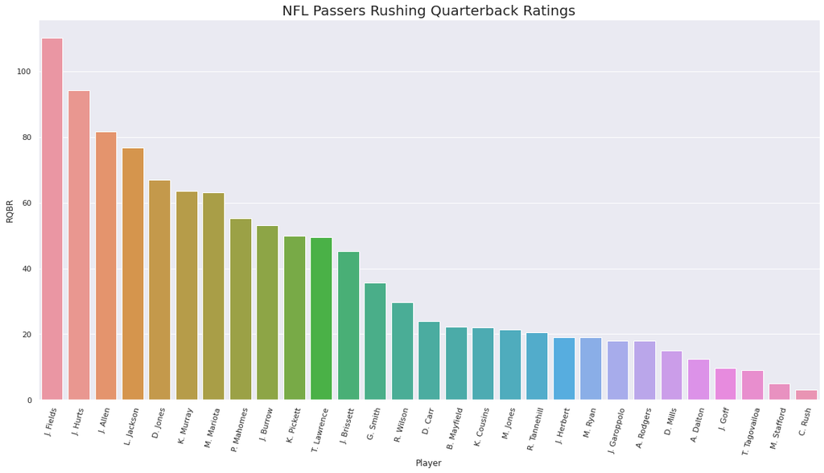

```python
# Create temp dataframe
temp = pd.DataFrame().assign(Player = rushingqbs_df["Player"], RQBR = rushingqbs_df["RQBR"])

# Create sns bar plot
sns.set(rc={'figure.figsize':(20,10)})
plt.xticks(rotation=75)
plt.title("NFL Passers Rushing Quarterback Ratings", fontsize=20)
sns.barplot(data = temp, x = 'Player', y = 'RQBR')
```

This is a bar plot of the RQBR metric we created. The order of the QBs is now different from when we plotted the normal QBR metric. However, one interesting note is that, while the order may be different, a good amount of the QBs in the QBR plot are still present in the RQBR plot. Patrick Mahomes for example is still in the top half of QBs based on rating values. This indicates that he is a great QB overall, having good passing and rushing abilities.

Now, we will create a new advanced QB metric which will be a combination of QBR and RQBR. We will use this to compare it to the typical QBR rating.

```python
# Create a rushing metric equivalent to quarterback rating
rushingqbs_df = rushingqbs_df.assign(AQBR = lambda x: x["QBR"] + (x["RQBR"] / 10))
rushingqbs_df = rushingqbs_df.sort_values(by='AQBR', ascending=False)
rushingqbs_df.head(5)
```

|  | Player | Position | Team | Games Played | Attempts | Rushing Yards | Rushing AVG | Rushing YPG | TDs | Win % | QBR | GamesPlayed | Sacked | RQBR | AQBR |
| --- | --- | --- | --- | --- | --- | --- | --- | --- | --- | --- | --- | --- | --- | --- | --- |
| 2 | J. Hurts | QB | Philadelphia | 12 | 132 | 609 | 4.6 | 50.8 | 9 | 91.7 | 108.3 | 12 | 30 | 94.2450 | 117.72450 |
| 28 | T. Tagovailoa | QB | Miami | 10 | 19 | 35 | 1.8 | 3.5 | 0 | 66.7 | 112.0 | 10 | 15 | 9.0375 | 112.90375 |
| 8 | G. Smith | QB | Seattle | 12 | 52 | 243 | 4.7 | 20.3 | 1 | 58.3 | 108.7 | 12 | 31 | 35.6775 | 112.26775 |
| 7 | P. Mahomes | QB | Kansas City | 12 | 44 | 283 | 6.4 | 23.6 | 2 | 75.0 | 104.9 | 12 | 19 | 55.3275 | 110.43275 |
| 10 | J. Burrow | QB | Cincinnati | 12 | 59 | 224 | 3.8 | 18.7 | 5 | 66.7 | 103.7 | 12 | 34 | 53.1450 | 109.01450 |

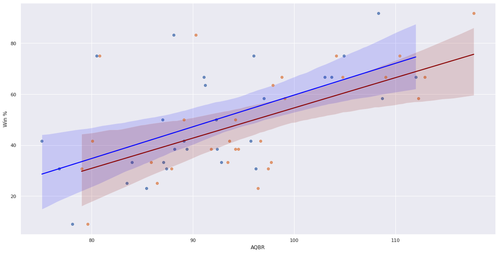

```
                            OLS Regression Results
==============================================================================
Dep. Variable:                    Win   R-squared:                       0.341
Model:                            OLS   Adj. R-squared:                  0.317
Method:                 Least Squares   F-statistic:                     14.00
Date:                Sat, 10 Dec 2022   Prob (F-statistic):           0.000874
Time:                        21:39:48   Log-Likelihood:                -122.12
No. Observations:                  29   AIC:                             248.2
Df Residuals:                      27   BIC:                             251.0
Df Model:                           1
Covariance Type:            nonrobust
==============================================================================
                 coef    std err          t      P>|t|      [0.025      0.975]
------------------------------------------------------------------------------
Intercept    -64.9016     30.753     -2.110      0.044    -128.002      -1.802
QBR            1.2455      0.333      3.741      0.001       0.562       1.929
==============================================================================
Omnibus:                        3.936   Durbin-Watson:                   1.587
Prob(Omnibus):                  0.140   Jarque-Bera (JB):                3.004
Skew:                           0.788   Prob(JB):                        0.223
Kurtosis:                       3.038   Cond. No.                         905.
==============================================================================

Notes:
[1] Standard Errors assume that the covariance matrix of the errors is correctly specified.
                            OLS Regression Results
==============================================================================
Dep. Variable:                    Win   R-squared:                       0.359
Model:                            OLS   Adj. R-squared:                  0.335
Method:                 Least Squares   F-statistic:                     15.09
Date:                Sat, 10 Dec 2022   Prob (F-statistic):           0.000600
Time:                        21:39:48   Log-Likelihood:                -121.74
No. Observations:                  29   AIC:                             247.5
Df Residuals:                      27   BIC:                             250.2
Df Model:                           1
Covariance Type:            nonrobust
==============================================================================
                 coef    std err          t      P>|t|      [0.025      0.975]
------------------------------------------------------------------------------
Intercept    -64.0151     29.399     -2.177      0.038    -124.336      -3.694
AQBR           1.1863      0.305      3.885      0.001       0.560       1.813
==============================================================================
Omnibus:                        6.202   Durbin-Watson:                   1.555
Prob(Omnibus):                  0.045   Jarque-Bera (JB):                4.415
Skew:                           0.862   Prob(JB):                        0.110
Kurtosis:                       3.826   Cond. No.                         913.
==============================================================================

Notes:
[1] Standard Errors assume that the covariance matrix of the errors is correctly specified.
```

```python
# Create plots
sns.regplot(data = rushingqbs_df, x = 'QBR', y = 'Win %', line_kws={'color':'blue'})
sns.regplot(data = rushingqbs_df, x = 'AQBR', y = 'Win %', line_kws={'color':'darkred'})

# Display the plots
plt.show()

# Create temp df for OLS use
temp = rushingqbs_df[['Win %','QBR', 'AQBR']].copy()
temp.rename(columns={'Win %': 'Win'}, inplace=True)

# Create OLS Information for Analysis
# Print OLS information for QBR and AQBR
info = ols(formula = 'Win ~ QBR', data = temp).fit()
print(info.summary())

info2 = ols(formula = 'Win ~ AQBR', data = temp).fit()
print(info2.summary())
```

The results may be surprising. The OLS regressions indicate no difference. That is no differecnce between QBR and AQBR as a predictor for winning percentages. From our previous statement that QBR is a good predictor already, we can conlcude that AQBR is good as well. Furthermore, we can say that a QB's rushing ability does not significantly impact winning percentage.

There could be a couple of reasons as to why. First, the current meta of the NFL. The meta is always changing (significant change can take seasons or even longer). The NFL is not stagnant. Maybe the current meta doesn't include a QB's rushing abililty to be an integral part of the game. In fact, a lot of QBs do not scramble often and some even despise it. For example, lets take a look at Tom Brady from the last few years of his career. He is an amazing, if not good QB. He has lead his teams into winning SuperBowl titles time and time again.

Additionally, our metric does give more insight into how QBs play. Our metric takes into account rushing yards which adds even more complexity to the normal QBR equation. On top of that, our metric is very similar in predicting win percentages as QBR. So we get the best of both worlds.

In conclusion, to put it into one sentence, a NFL team's success comes from their offensive ability to score more than anything.